# Heart Disease Prediction System Using Machine Learning

# Name: D. M. Khalid Mahmud

# ID: 1901004

# Name: MD. Al Morsaline

# ID: 1901020

```python
import pandas as pd
import matplotlib.pyplot as plt
import seaborn as sns
import numpy as np
from sklearn import model_selection

# accuracy
from sklearn.metrics import roc_curve, auc
from sklearn.metrics import accuracy_score
from sklearn.metrics import classification_report
from sklearn.metrics import confusion_matrix
from sklearn.metrics import precision_score
from sklearn.metrics import roc_auc_score

# algorithms
from sklearn.linear_model import LogisticRegression
from sklearn.tree import DecisionTreeClassifier
from sklearn.ensemble import RandomForestClassifier, ExtraTreesClassifier #extra trees for feature selection/importance
from sklearn.neighbors import KNeighborsClassifier
from sklearn.naive_bayes import GaussianNB
from sklearn.svm import SVC

# parameter tuning
from sklearn.model_selection import GridSearchCV
```

```python
df = pd.read_csv("heart.csv")
print(df)
```

```
      age  sex  cp  trestbps  chol  fbs  restecg  thalach  exang  oldpeak  \
0      52    1   0       125   212    0        1      168      0      1.0
1      53    1   0       140   203    1        0      155      1      3.1
2      70    1   0       145   174    0        1      125      1      2.6
3      61    1   0       148   203    0        1      161      0      0.0
4      62    0   0       138   294    1        1      106      0      1.9
...   ...  ...  ..       ...   ...  ...      ...      ...    ...      ...
1020   59    1   1       140   221    0        1      164      1      0.0
1021   60    1   0       125   258    0        0      141      1      2.8
1022   47    1   0       110   275    0        0      118      1      1.0
1023   50    0   0       110   254    0        0      159      0      0.0
1024   54    1   0       120   188    0        1      113      0      1.4

      slope  ca  thal  target
0         2   2     3       0
1         0   0     3       0
2         0   0     3       0
3         2   1     3       0
4         1   3     2       0
...     ...  ..   ...     ...
1020      2   0     2       1
1021      1   1     3       0
1022      1   1     2       0
1023      2   0     2       1
1024      1   1     3       0

[1025 rows x 14 columns]
```

# Data Exploration

# 1. Total Number of Rows and Columns

```python
# Number of Rows and Columns
print(df.shape)
```

```
(1025, 14)
```

# 2. Peeking at the Data

```python
# Peeking at the Data
df.head() # Prints the first 5 rows
```

|  | age | sex | cp | trestbps | chol | fbs | restecg | thalach | exang | oldpeak | slope | ca | thal | target |
| --- | --- | --- | --- | --- | --- | --- | --- | --- | --- | --- | --- | --- | --- | --- |
| 0 | 52 | 1 | 0 | 125 | 212 | 0 | 1 | 168 | 0 | 1.0 | 2 | 2 | 3 | 0 |
| 1 | 53 | 1 | 0 | 140 | 203 | 1 | 0 | 155 | 1 | 3.1 | 0 | 0 | 3 | 0 |
| 2 | 70 | 1 | 0 | 145 | 174 | 0 | 1 | 125 | 1 | 2.6 | 0 | 0 | 3 | 0 |
| 3 | 61 | 1 | 0 | 148 | 203 | 0 | 1 | 161 | 0 | 0.0 | 2 | 1 | 3 | 0 |
| 4 | 62 | 0 | 0 | 138 | 294 | 1 | 1 | 106 | 0 | 1.9 | 1 | 3 | 2 | 0 |

# 3. Data Types of Each Feature

```python
# Data Types
df.dtypes
```

```
age           int64
sex           int64
cp            int64
trestbps      int64
chol          int64
fbs           int64
restecg       int64
thalach       int64
exang         int64
oldpeak     float64
slope         int64
ca            int64
thal          int64
target        int64
dtype: object
```

# 4. Dataset Information

```python
# Dataset Information
print(df.info())
```

```
<class 'pandas.core.frame.DataFrame'>
RangeIndex: 1025 entries, 0 to 1024
Data columns (total 14 columns):
 #   Column    Non-Null Count  Dtype
---  ------    --------------  -----
 0   age       1025 non-null   int64
 1   sex       1025 non-null   int64
 2   cp        1025 non-null   int64
 3   trestbps  1025 non-null   int64
 4   chol      1025 non-null   int64
 5   fbs       1025 non-null   int64
 6   restecg   1025 non-null   int64
 7   thalach   1025 non-null   int64
 8   exang     1025 non-null   int64
 9   oldpeak   1025 non-null   float64
 10  slope     1025 non-null   int64
 11  ca        1025 non-null   int64
 12  thal      1025 non-null   int64
 13  target    1025 non-null   int64
dtypes: float64(1), int64(13)
memory usage: 112.2 KB
None
```

# 5. Statistical Summary

```python
# Statistical Summary
df.describe()
```

|  | age | sex | cp | trestbps | chol | fbs | restecg | thalach | exang | oldpeak | slope | ca | thal | target |
| --- | --- | --- | --- | --- | --- | --- | --- | --- | --- | --- | --- | --- | --- | --- |
| count | 1025.000000 | 1025.000000 | 1025.000000 | 1025.000000 | 1025.00000 | 1025.000000 | 1025.000000 | 1025.000000 | 1025.000000 | 1025.000000 | 1025.000000 | 1025.000000 | 1025.000000 | 1025.000000 |
| mean | 54.434146 | 0.695610 | 0.942439 | 131.611707 | 246.00000 | 0.149268 | 0.529756 | 149.114146 | 0.336585 | 1.071512 | 1.385366 | 0.754146 | 2.323902 | 0.513171 |
| std | 9.072290 | 0.460373 | 1.029641 | 17.516718 | 51.59251 | 0.356527 | 0.527878 | 23.005724 | 0.472772 | 1.175053 | 0.617755 | 1.030798 | 0.620660 | 0.500070 |
| min | 29.000000 | 0.000000 | 0.000000 | 94.000000 | 126.00000 | 0.000000 | 0.000000 | 71.000000 | 0.000000 | 0.000000 | 0.000000 | 0.000000 | 0.000000 | 0.000000 |
| 25% | 48.000000 | 0.000000 | 0.000000 | 120.000000 | 211.00000 | 0.000000 | 0.000000 | 132.000000 | 0.000000 | 0.000000 | 1.000000 | 0.000000 | 2.000000 | 0.000000 |
| 50% | 56.000000 | 1.000000 | 1.000000 | 130.000000 | 240.00000 | 0.000000 | 1.000000 | 152.000000 | 0.000000 | 0.800000 | 1.000000 | 0.000000 | 2.000000 | 1.000000 |
| 75% | 61.000000 | 1.000000 | 2.000000 | 140.000000 | 275.00000 | 0.000000 | 1.000000 | 166.000000 | 1.000000 | 1.800000 | 2.000000 | 1.000000 | 3.000000 | 1.000000 |
| max | 77.000000 | 1.000000 | 3.000000 | 200.000000 | 564.00000 | 1.000000 | 2.000000 | 202.000000 | 1.000000 | 6.200000 | 2.000000 | 4.000000 | 3.000000 | 1.000000 |

# Univariate Analysis

# 1. Age Distribution of Patients

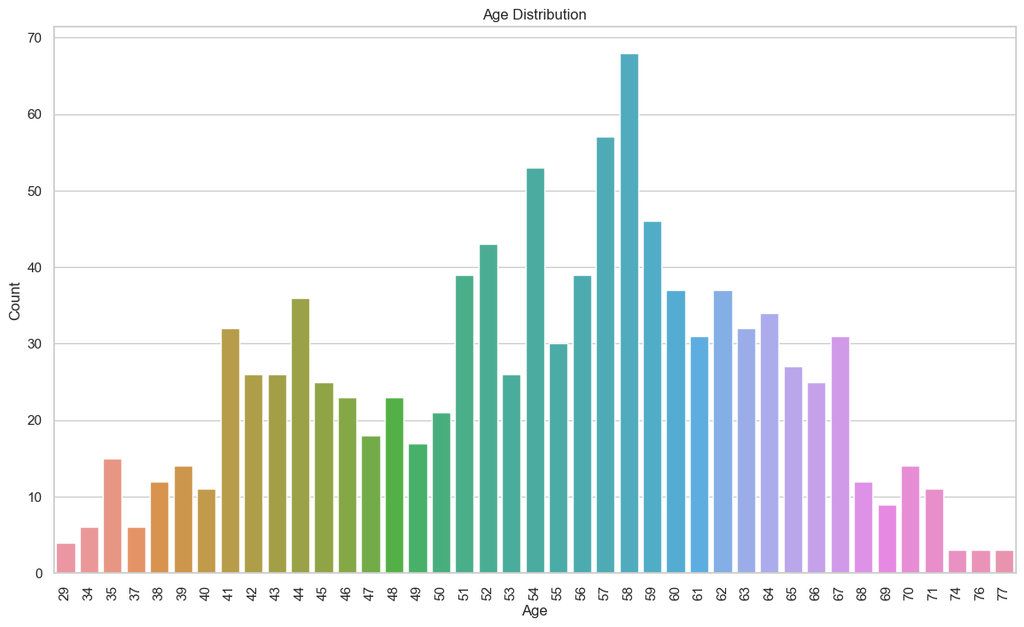

```python
df_sorted = df.sort_values(by='age')

plt.figure(figsize=(14, 8))  # Size of the figure
sns.set(style="whitegrid")  # Background grid
sns.countplot(x='age', data=df_sorted)
plt.xlabel('Age')
plt.ylabel('Count')
plt.title('Age Distribution')
plt.xticks(rotation=90)  # Rotate x-axis labels for better readability
plt.show()
```

This count plot histogram displays the age distribution of all the patients. We can see from the histogram that the highest number of patients are 58 years old.

# 2. Gender Distribution of Patients

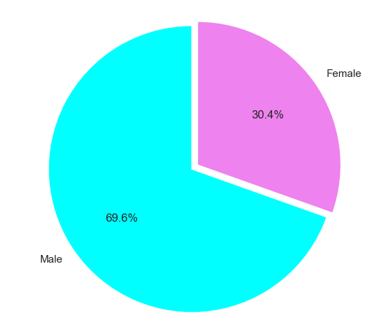

```python
# Pie chart for the feature 'sex' to find out gender distribution
male = len(df[df['sex'] == 1]) # Assign variable 'male' as the length of '1' in the feature 'sex'
female = len(df[df['sex'] == 0]) # Assign variable 'female' as the length of '0' in the feature'sex'
labels = 'Male','Female'
sizes = [male, female]
colors = ['cyan', 'violet']
explode = (0, 0.05)  # Only the second slice will explode

plt.figure(figsize=(7,6)) # Size of the figure
plt.pie(sizes, explode=explode, labels=labels, colors=colors,
autopct='%1.1f%%', shadow=False, startangle=90)

plt.axis('equal') # Ensure that the pie chart is drawn as a circle
plt.show()
```

This pie chart illustrates the gender distribution of all patients. Based on this chart, we can see that a higher majority of the patients are male.

# 3. Chest Pain Types

```python
# Frequency distribution of the feature 'cp'
df.cp.value_counts() # Prints the total count of each value in the feature
```

```
cp
0    497
2    284
1    167
3     77
Name: count, dtype: int64
```

# Value - Chest Pain Type

# 0 - Typical Angina

# 1 - Atypical Angina

# 2 - Non-anginal Pain

# 3 - Asymptomatic

Based on the corresponding chest pain type for each value, we can see from the output that the highest number of patients experience typical angina, which are normal chest pains, whereas the lowest number of patients experience asymptomatic chest pain. Using this frequency distribution, we can check whether the pie chart below has been plotted accurately.

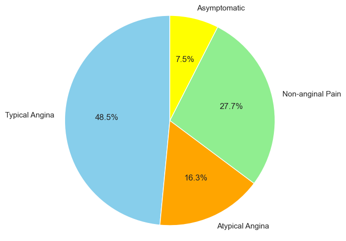

```python
# Pie chart for the feature 'cp' to find out percentage of each chest pain type
cpOne = len(df[df['cp'] == 0]) # Assign variable 'cpOne' as the length of '0' in the feature 'cp'
cpTwo = len(df[df['cp'] == 1]) # Assign variable 'cpTwo' as the length of '1' in the feature 'cp'
cpThree = len(df[df['cp'] == 2]) # Assign variable 'cpThree' as the length of '2' in the feature 'cp'
cpFour = len(df[df['cp'] == 3]) # Assign variable 'cpFour' as the length of '3' in the feature 'cp'

labels = 'Typical Angina','Atypical Angina', 'Non-anginal Pain', 'Asymptomatic'
sizes = [cpOne, cpTwo, cpThree, cpFour ]
explode = (0, 0, 0, 0)  # None of the slices will explode
colors = ['skyblue', 'orange', 'lightgreen', 'yellow']

plt.figure(figsize=(7,6)) # Size of the figure
plt.pie(sizes, explode=explode, labels=labels, colors=colors,
autopct='%1.1f%%', shadow=False, startangle=90)

plt.axis('equal') # Ensure that the pie chart is drawn as a circle
plt.show()
```

# 4. Blood Pressure

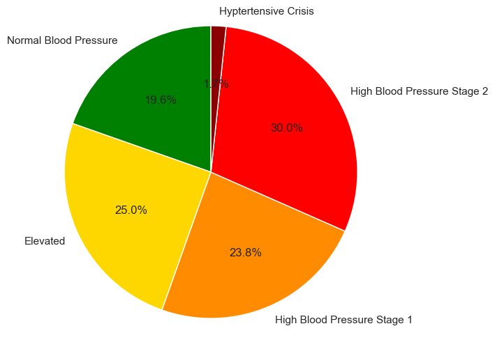

```
Total Count: 1025
```

```python
# Pie chart for the feature 'trestbps' to find out the percentage of patients in each blood pressure stage, according to Health.org
normal = len(df[df['trestbps'] < 120]) # Assign variable 'normal' as the length of values < 120
elevated = len(df[df['trestbps'].between(120, 129)]) # Assign variable 'elevated' as the length of values between 120 and 129
hbpOne = len(df[df['trestbps'].between(130, 139)]) # Assign variable 'hbpOne' as the length of values between 130 and 139
hbpTwo = len(df[df['trestbps'].between(140, 179)]) # Assign variable 'hbpTwo' as the length of values between 140 and 180
crisis = len(df[df['trestbps'] >= 180]) # Assign variable 'crisis' as the length of values >= 180

labels = 'Normal Blood Pressure','Elevated', 'High Blood Pressure Stage 1', 'High Blood Pressure Stage 2', 'Hyptertensive Crisis'
sizes = [normal, elevated, hbpOne, hbpTwo, crisis]
explode = (0, 0, 0, 0, 0)  # None of the slices will explode
colors = ['green', 'gold', 'darkorange', 'red', 'darkred']

plt.figure(figsize=(7,6)) # Size of the figure
plt.pie(sizes, explode=explode, labels=labels, colors=colors,
autopct='%1.1f%%', shadow=False, startangle=90)

plt.axis('equal') # Ensure that the pie chart is drawn as a circle
plt.show()

print("Total Count:", normal + elevated + hbpOne + hbpTwo + crisis) # For checking
```

This pie chart illustrates the percentage of patients in each blood pressure category. Surprisingly, more than half of all the patients have high blood pressure, with the highest percentage of patients having stage 2 high blood pressure, and the lowest percentage having hypertensive crisis.

```python
# Total count for the feature 'trestbps'
df.trestbps.count() # Done to check for any missing values during the plotting of the above pie chart
```

```
1025
```

Based on the output, we can tell that there are no missing values.

# 5. Cholesterol Levels

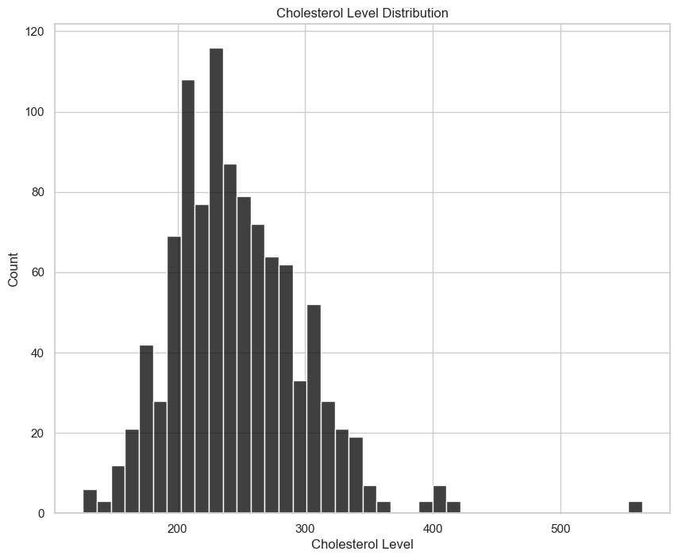

```python
plt.figure(figsize=(10, 8))  # Size of the figure
sns.set(style="whitegrid")  # Background grid

# Use sns.histplot for the distribution plot
sns.histplot(df['chol'], kde=False, bins=40, color="black")  # bins specifies the number of bins in the histogram

plt.xlabel('Cholesterol Level')
plt.ylabel('Count')
plt.title('Cholesterol Level Distribution')
plt.show()
```

From this distribution plot, we can see that the highest number of patients have a cholesterol level of around 240 mg/dl.

# 6. Fasting Blood Sugar

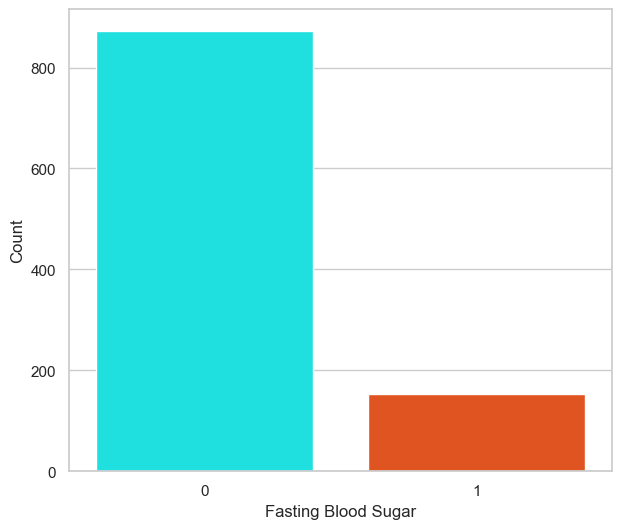

```python
plt.figure(figsize=(7, 6))  # Size of the figure
sns.set(style="whitegrid")  # Background grid
sns.countplot(x='fbs', data=df, palette=["aqua", "orangered"], order=[0, 1])  # Specify the order explicitly
plt.xlabel('Fasting Blood Sugar')
plt.ylabel('Count')
plt.show()
```

# Value - Blood Sugar Level

# 0 - <120 mg/dl

# 1 - >120 mg/dl

Based on this histogram, a larger majority of the patients have a fasting blood sugar level of <120 mg/dl, with only a small number of patients having a fasting blood sugar level of >120 mg/dl. Patients who have a fasting blood sugar level of >125 mg/dl are most likely to have diabetes.

# 7. Exercise Induced Angina

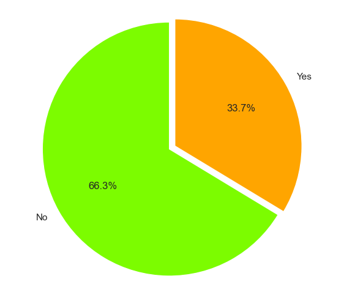

```python
# Pie chart for the feature 'exang' to find out the percentage of patients who have and do not have exercise induced angina
noExang = len(df[df['exang'] == 0]) # Assign variable 'noExang' as the length of '0' in the feature 'exang'
yesExang = len(df[df['exang'] == 1]) # Assign variable 'female' as the length of '1' in the feature'exang'
labels = 'No','Yes'
sizes = [noExang, yesExang]
colors = ['lawngreen', 'orange']
explode = (0, 0.05)  # Only the second slice will explode

plt.figure(figsize=(7,6)) # Size of the figure
plt.pie(sizes, explode=explode, labels=labels, colors=colors,
autopct='%1.1f%%', shadow=False, startangle=90)

plt.axis('equal') # Ensure that the pie chart is drawn as a circle
plt.show()
```

Based on this pie chart, we can tell that close to two-thirds of all the patients do not have exercise induced angina, whereas only one-third experience it, meaning that during physical activity, these patients would have symptoms of pressure and aching in different areas of their body

# 8. Patients Diagnosed with Heart Disease

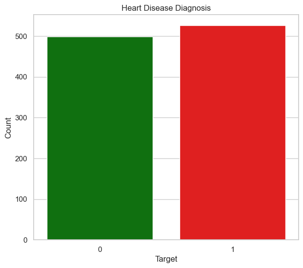

```python
# Count plot histogram for the featuer 'target' to find out the number of patients who have or have not been diagnosed with a heart disease

plt.figure(figsize=(7, 6))  # Size of the figure
sns.set(style="whitegrid")  # Background grid
sns.countplot(x='target', data=df, palette=["green", "red"])
plt.xlabel('Target')
plt.ylabel('Count')
plt.title('Heart Disease Diagnosis')
plt.show()
```

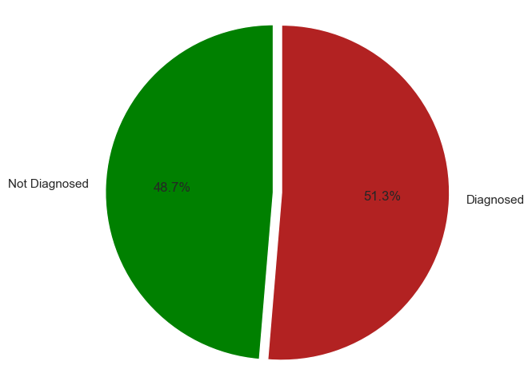

```python
# Pie chart for the feature 'sex' to find out gender distribution
nodisease = len(df[df['target'] == 0]) # Assign variable 'female' as the length of '0' in the feature'sex'
yesdisease = len(df[df['target'] == 1]) # Assign variable 'male' as the length of '1' in the feature 'sex'
labels = 'Not Diagnosed','Diagnosed'
sizes = [nodisease, yesdisease]
colors = ['green', 'firebrick']
explode = (0, 0.05)  # Only the second slice will explode

plt.figure(figsize=(7,6)) # Size of the figure
plt.pie(sizes, explode=explode, labels=labels, colors=colors,
autopct='%1.1f%%', shadow=False, startangle=90)

plt.axis('equal') # Ensure that the pie chart is drawn as a circle
plt.show()
```

# Value ---- Does the patient have a heart disease?

# 0 ---- No

# 1 ---- Yes

This is a very important feature that determines whether the patient has a heart disease. Based on this histogram, we can see that a larger number of patients have been diagnosed with heart disease.

# Bivariate Analysis

# 1. Relationship between Age and Target

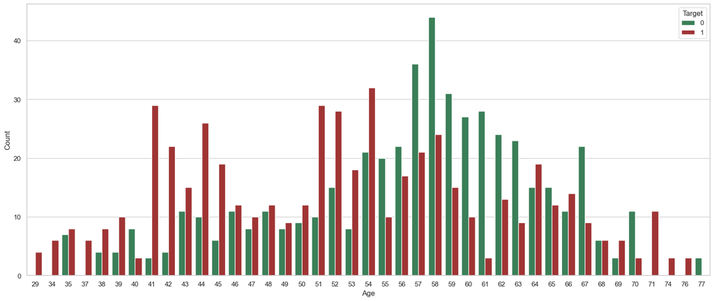

```python
# Count plot histogram to visualize the relationship between the features 'age' and 'target'
plt.figure(figsize=(20,8)) # Size of the figure
sns.countplot(data=df, x='age', hue = 'target', palette=["seagreen", "firebrick"])
plt.legend(loc='upper right', title="Target") # Location and title of legend
plt.xlabel('Age')
plt.ylabel('Count')
plt.show()
```

From this histogram, we can clearly see that the highest number of patients who have a heart disease are 54 years old.

# 2. Relationship between Age and Trestbps (Resting Blood Pressure)

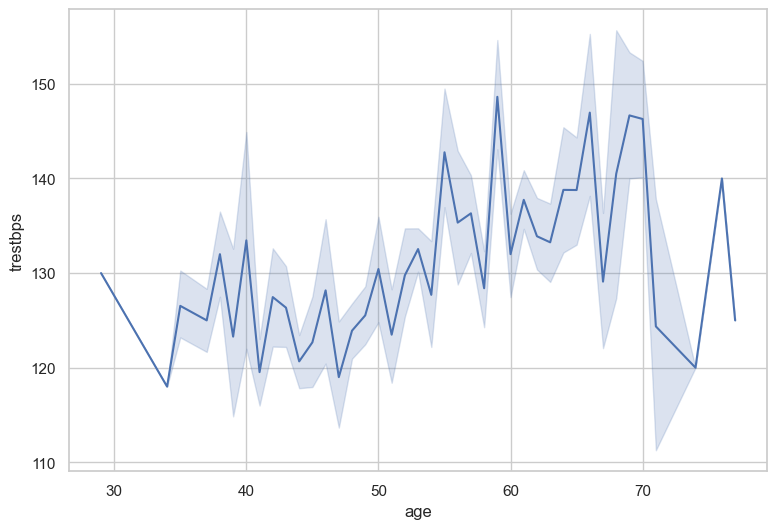

```python
# Line plot to visualize the relationship between the features 'age' and 'trestbps'
plt.figure(figsize=(9,6)) # Size of the figure
sns.lineplot(x="age", y="trestbps", data=df)
plt.show()
```

From this line plot, we can tell that as age increases, trestbps also increases. The blood pressure of a person would increase as they age.

# 3. Relationship between Age and Thalach (Maximum Heart Rate)

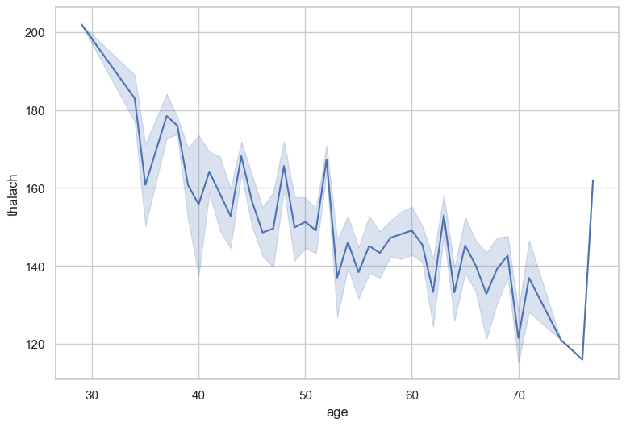

```python
# Line plot to visualize the relationship between the features 'age' and 'thalach'
plt.figure(figsize=(9,6)) # Size of the figure
sns.lineplot(x="age", y="thalach", data=df)
plt.show()
```

From this line plot, we can see that there is a decrease in the maximum heart rate as the age increases. This is understandable, as when one ages, the rate at which the heart pumps is lowered.

# 4. Relationship between Sex (Gender) and Target

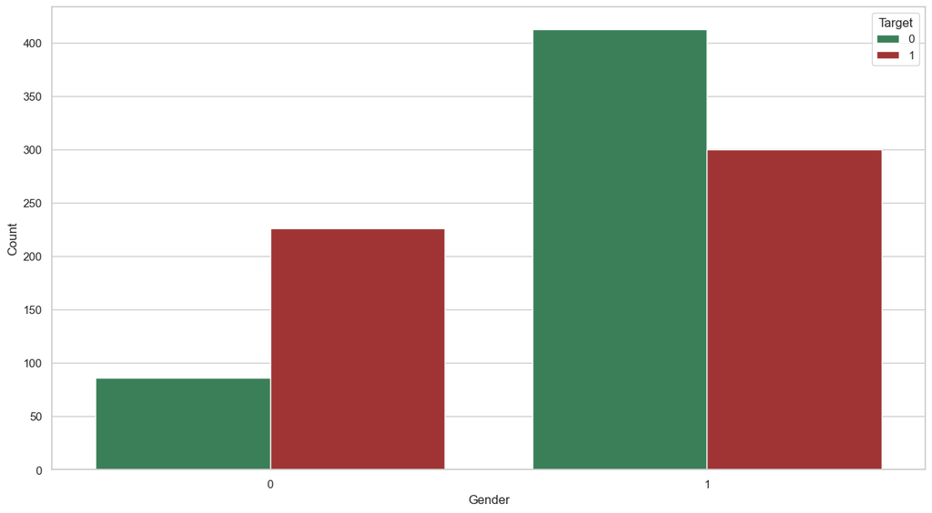

```python
# Count plot histogram to visualize the relationship between the features 'sex' and 'target'
sns.set(style="whitegrid") # Background grid
plt.figure(figsize=(15,8)) # Size of the figure
sns.countplot(data=df, x='sex', hue = 'target', palette=["seagreen", "firebrick"])
plt.legend(loc='upper right', title="Target") # Location and title of legend
plt.xlabel('Gender')
plt.ylabel('Count')
plt.show()
```

1 for male and 0 for female. At first glance, we can tell that males are at a higher risk of developing a heart disease. However, we also have to take into consideration that the number of male patients in this dataset is significantly higher than that of the number of female patients.

# 5. Relationship between Trestbps (Resting Blood Pressure) and Target

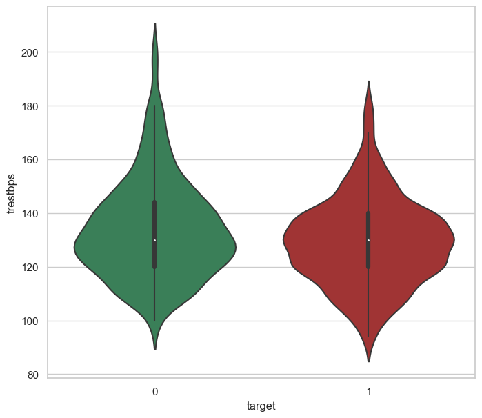

```python
# Violin plot to visualize the relationship between 'trestbps' and 'target'
sns.set(style="whitegrid") # Background grid
plt.rcParams['figure.figsize'] = (8, 7)
sns.violinplot(data=df, x='target', y='trestbps', palette=["seagreen", "firebrick"])
plt.show()
```

According to WebMD, high blood pressure can lead to a heart disease. However, according to this violin plot, we are unable to make that conclusion as patients with a high blood pressure have not been diagnosed with a heart disease. Hence, we cannot say for sure that high blood pressure can lead to a heart disease.

# 6. Relationship between Chol and Target

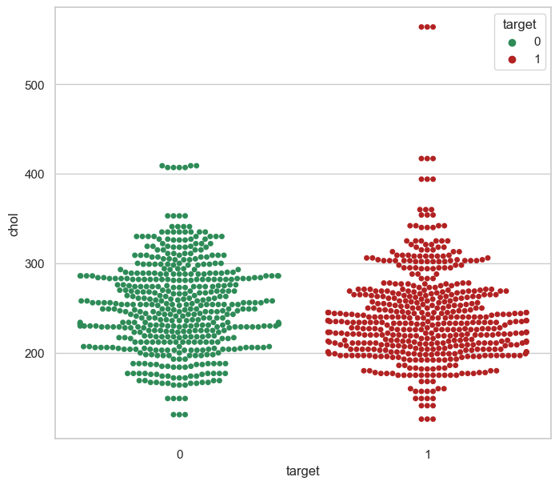

```python
# Swarm plot to visualize the relationship between 'chol' and 'target'
sns.set(style="whitegrid") # Background grid
plt.rcParams['figure.figsize'] = (8, 7)
sns.swarmplot(data=df, x='target', y='chol', hue='target', palette=["seagreen", "firebrick"])
plt.show()
```

Based on this swarm plot, we are unable to tell whether there is a relation between cholesterol levels and heart disease due to the similarity of the cholesterol levels. However, according to Mayo Clinic, when there is too much cholesterol in your blood, the risk of having a heart disease is increased.

# 7. Relationship between Thalach (Maximum Heart Rate) and Target

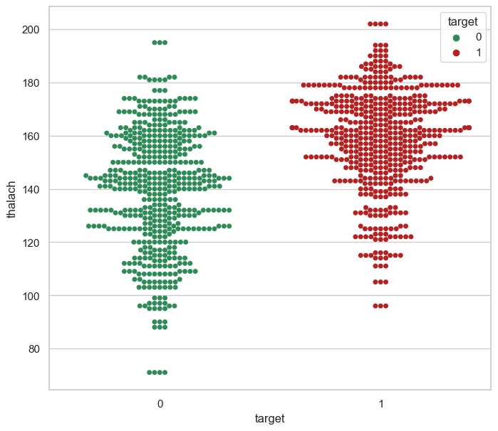

```python
# Swarm plot to visualize the relationship between 'chol' and 'target'
sns.set(style="whitegrid") # Background grid
plt.rcParams['figure.figsize'] = (8, 7)
sns.swarmplot(data=df, x='target', y='thalach',hue='target', palette=["seagreen", "firebrick"])
plt.show()
```

Based on this swarm plot, we can tell that the higher the maximum heart rate of a patient, the more likely they are to have a heart disease.

# Multivariate Analysis

# 1. Relationship between Chol (Cholesterol Level), Thalach (Maximum Heart Rate) and Target

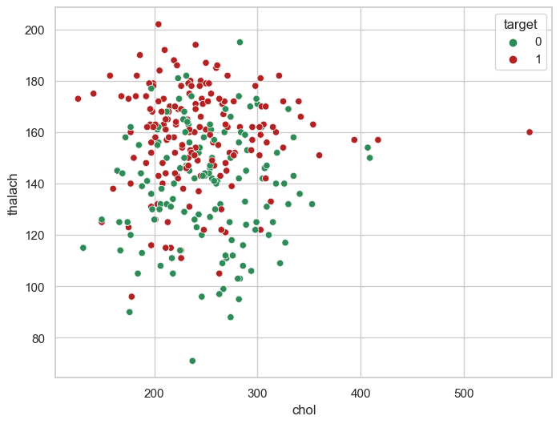

```python
sns.set(style="whitegrid") # Background grid
plt.figure(figsize=(8,6))
sns.scatterplot(x='chol',y='thalach',data=df,hue='target', palette=["seagreen", "firebrick"])
plt.show()
```

# Data Preparation

Check for any null values in every feature. If there are null values, depending on the number of them, we will either drop them using dropna() or fill them with fillna() using the mean/median value.

Change the feature names for clearer understanding.

# 1. Checking for any null (missing) values

```python
df.isnull().sum()
```

```
age         0
sex         0
cp          0
trestbps    0
chol        0
fbs         0
restecg     0
thalach     0
exang       0
oldpeak     0
slope       0
ca          0
thal        0
target      0
dtype: int64
```

There are no missing values in all of the features.

# Correlation

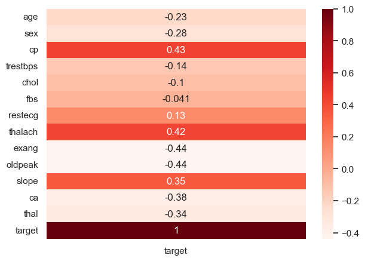

```python
target_correlation = df.corr()[['target']]
plt.figure(figsize=(7,5))
sns.heatmap(target_correlation, annot=True, cmap=plt.cm.Reds)
plt.show()
```

Let's separate our features into categorical and numerical features:

```python
cat_col = ['sex', 'cp', 'fbs', 'restecg', 'exang', 'slope', 'ca', 'thal']
num_col = ['age', 'trestbps', 'chol', 'thalach', 'oldpeak']
```

First let's check the correlation between the categorical features

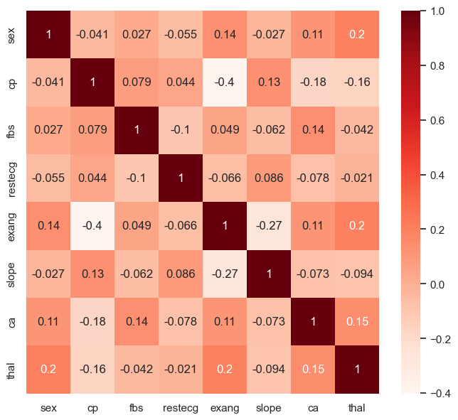

```python
sns.heatmap(df.corr().loc[cat_col, cat_col], annot=True, cmap=plt.cm.Reds)
plt.show()
```

Then we check the correlation between the numerical features

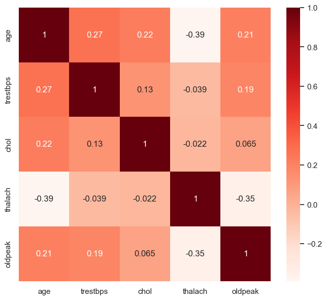

```python
sns.heatmap(df.corr().loc[num_col, num_col], annot=True, cmap=plt.cm.Reds)
plt.show()
```

Finally, we check the correlation between all the features and the target

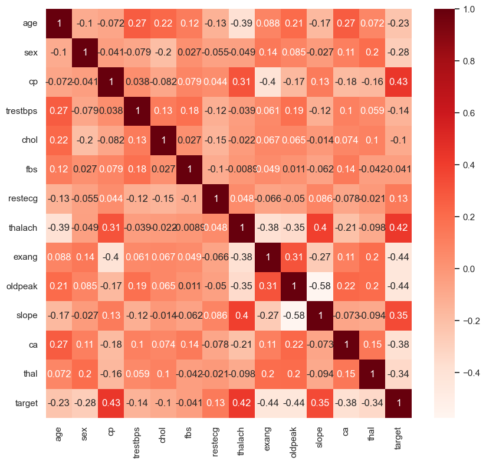

```python
plt.figure(figsize=(10, 9))   #you can adjust the plot size here
sns.heatmap(df.corr().loc[df.columns, df.columns], annot=True, cmap=plt.cm.Reds)
plt.show()
```

Next pairplot Showing the relationships between the numerical features and the distribution of the data in each feature :

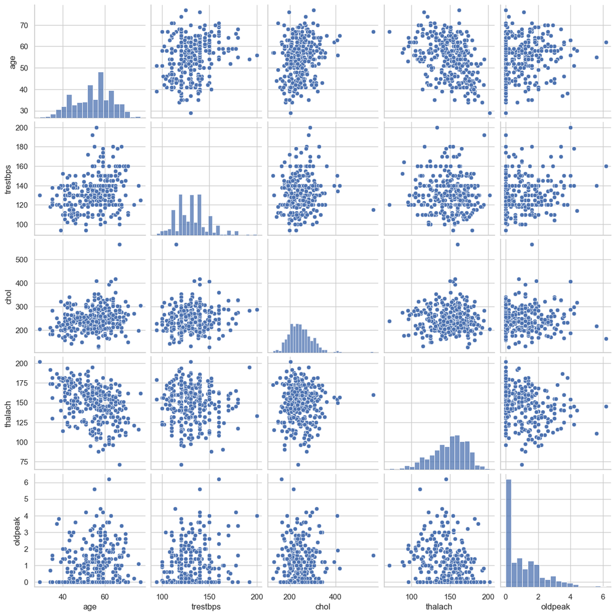

```python
sns.pairplot(df[num_col]);
```

# Outliers

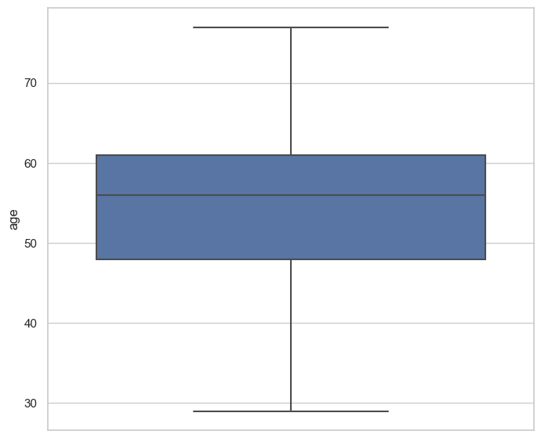

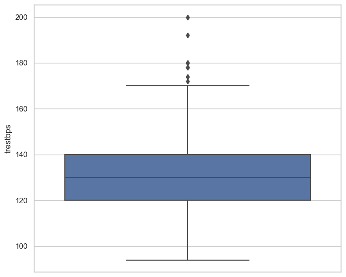

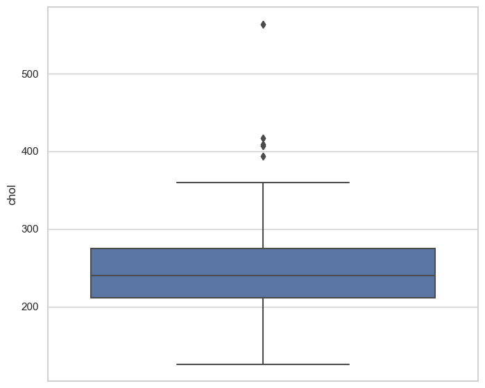

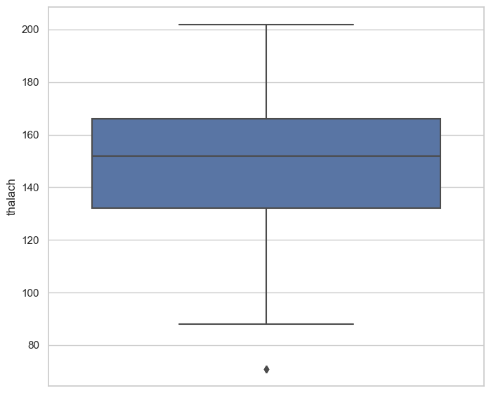

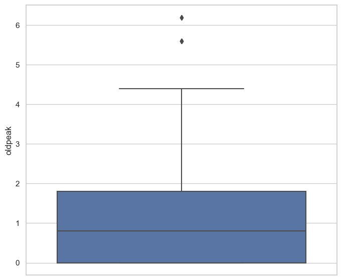

```python
for col in num_col:
    sns.boxplot(data = df, y = col)
    plt.show()
```

Now, manually remove the outliers

```python
df = df.drop(df[(df["trestbps"] >= 170) | (df["chol"] >= 380)\
                     | (df['thalach'] <= 90) | (df['oldpeak'] > 4)].index)
```

Check after removing outliers

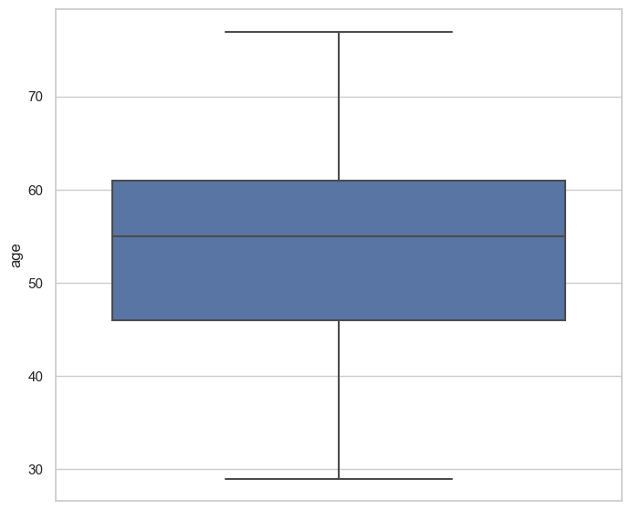

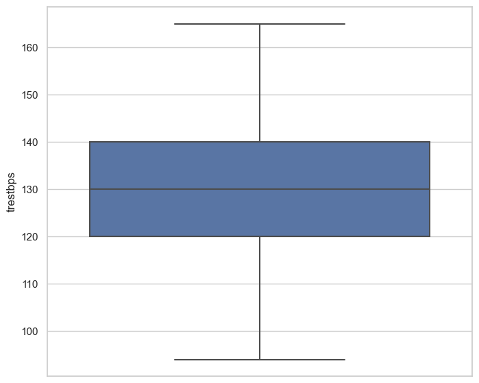

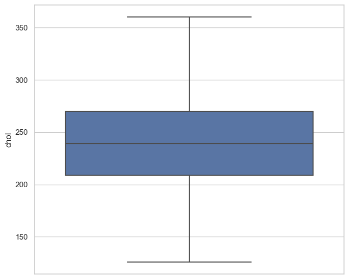

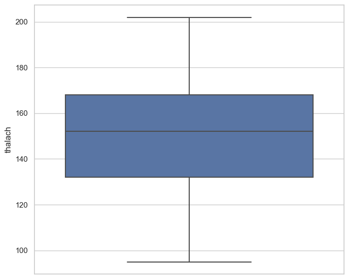

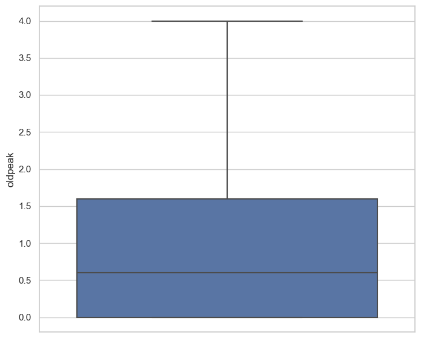

```python
for col in num_col:
    sns.boxplot(data = df, y = col)
    plt.show()
```

Let's check how much rows did we remove, the original dataset had 1025 rows

```python
df.shape
```

```
(940, 14)
```

# 2. Changing Feature (Column) Names

As the original names of the features were too unclear, they will be changed to prevent any further confusion.

```python
df.head()
```

|  | age | sex | cp | trestbps | chol | fbs | restecg | thalach | exang | oldpeak | slope | ca | thal | target |
| --- | --- | --- | --- | --- | --- | --- | --- | --- | --- | --- | --- | --- | --- | --- |
| 0 | 52 | 1 | 0 | 125 | 212 | 0 | 1 | 168 | 0 | 1.0 | 2 | 2 | 3 | 0 |
| 1 | 53 | 1 | 0 | 140 | 203 | 1 | 0 | 155 | 1 | 3.1 | 0 | 0 | 3 | 0 |
| 2 | 70 | 1 | 0 | 145 | 174 | 0 | 1 | 125 | 1 | 2.6 | 0 | 0 | 3 | 0 |
| 3 | 61 | 1 | 0 | 148 | 203 | 0 | 1 | 161 | 0 | 0.0 | 2 | 1 | 3 | 0 |
| 4 | 62 | 0 | 0 | 138 | 294 | 1 | 1 | 106 | 0 | 1.9 | 1 | 3 | 2 | 0 |

We will be using this to confirm the changes to the feature names.

```python
# Changing feature (column) names
df.columns = ['age', 'sex', 'chest_pain', 'rest_blood_pressure', 'cholesterol', 'fast_blood_sugar', 'rest_ecg', 'max_heart_rate',
       'exercise_induced_angina', 'st_depression', 'st_slope', 'num_major_vessels', 'thalassaemia', 'target']

df.head() # Prints the first 5 rows to view the changes made
```

|  | age | sex | chest_pain | rest_blood_pressure | cholesterol | fast_blood_sugar | rest_ecg | max_heart_rate | exercise_induced_angina | st_depression | st_slope | num_major_vessels | thalassaemia | target |
| --- | --- | --- | --- | --- | --- | --- | --- | --- | --- | --- | --- | --- | --- | --- |
| 0 | 52 | 1 | 0 | 125 | 212 | 0 | 1 | 168 | 0 | 1.0 | 2 | 2 | 3 | 0 |
| 1 | 53 | 1 | 0 | 140 | 203 | 1 | 0 | 155 | 1 | 3.1 | 0 | 0 | 3 | 0 |
| 2 | 70 | 1 | 0 | 145 | 174 | 0 | 1 | 125 | 1 | 2.6 | 0 | 0 | 3 | 0 |
| 3 | 61 | 1 | 0 | 148 | 203 | 0 | 1 | 161 | 0 | 0.0 | 2 | 1 | 3 | 0 |
| 4 | 62 | 0 | 0 | 138 | 294 | 1 | 1 | 106 | 0 | 1.9 | 1 | 3 | 2 | 0 |

We can see that the feature names have been changed.

# Feature Selection

# Extra Trees Classifier

```
 fast_blood_sugar - 2.000089%
 rest_ecg - 3.473420%
 st_slope - 5.691448%
 rest_blood_pressure - 6.129282%
 sex - 6.251997%
 cholesterol - 6.329604%
 age - 7.287590%
 max_heart_rate - 8.837272%
 st_depression - 9.493920%
 exercise_induced_angina - 9.655796%
 thalassaemia - 11.175151%
 chest_pain - 11.685367%
 num_major_vessels - 11.989065%
```

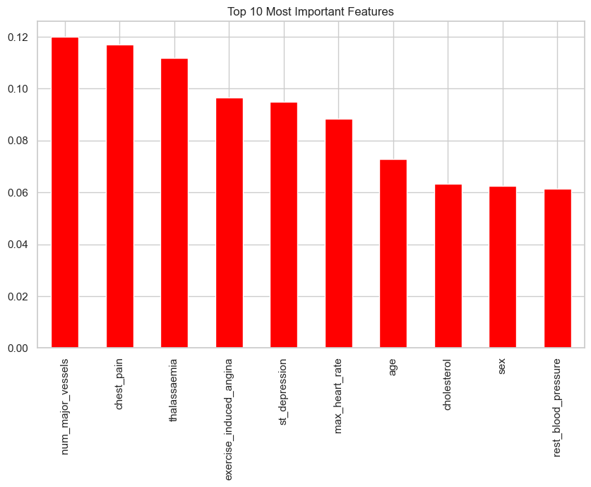

```python
X = df.iloc[:,0:13]  # independent columns
Y = df.iloc[:,-1] # target column

extratrees = ExtraTreesClassifier(n_estimators=250 , random_state=0) # n_estimators is the number of trees that will be in the forest
extratrees.fit(X,Y)
sns.set(style="whitegrid") # Background grid
plt.figure(figsize=(10,6))
plt.title("Top 10 Most Important Features")

feat_importances = pd.Series(extratrees.feature_importances_, index=X.columns)
feat_importances.nlargest(10).plot(kind='bar', color='red') # nlargest() returns the first 10 rows with the largest values

feature_labels=np.array(X.columns)

importance = extratrees.feature_importances_

feature_indexes_by_importance = importance.argsort()

for index in feature_indexes_by_importance:
    print(" {} - {:2f}%".format( feature_labels[index], (importance[index] * 100.0)))

plt.show()
```

# 3. Dropping Unselected Features

```python
del df['sex']
del df['rest_ecg']
del df['fast_blood_sugar']

df.head()
```

|  | age | chest_pain | rest_blood_pressure | cholesterol | max_heart_rate | exercise_induced_angina | st_depression | st_slope | num_major_vessels | thalassaemia | target |
| --- | --- | --- | --- | --- | --- | --- | --- | --- | --- | --- | --- |
| 0 | 52 | 0 | 125 | 212 | 168 | 0 | 1.0 | 2 | 2 | 3 | 0 |
| 1 | 53 | 0 | 140 | 203 | 155 | 1 | 3.1 | 0 | 0 | 3 | 0 |
| 2 | 70 | 0 | 145 | 174 | 125 | 1 | 2.6 | 0 | 0 | 3 | 0 |
| 3 | 61 | 0 | 148 | 203 | 161 | 0 | 0.0 | 2 | 1 | 3 | 0 |
| 4 | 62 | 0 | 138 | 294 | 106 | 0 | 1.9 | 1 | 3 | 2 | 0 |

# Algorithms

The algorithms that we will be using are:

1. Decision Tree Classifier (DTC)
1. Random Forest Classifier (RFC)
1. Logistic Regression (LR)
1. K-Neighbors Classifier (KNN)
1. Support Vector Machines (SVM)
1. Naive Bayes (NB)

# 1. Splitting the Dataset into Training and Testing Sets

```python
X = df.iloc[:,0:10]
Y = df.iloc[:,-1]

X_train, X_test, Y_train, Y_test = model_selection.train_test_split(X, Y, test_size=0.2, random_state=0)
```

We will split the dataset into training and testing sets. The training set will be 80%, and the testing set will be 20% of the dataset. We then have data in X_train and Y_train that will be used to prepare the classification models, and X_test and Y_test that will be used for testing the accuracy of the models.

# 2. Using K-Fold Cross Validation

```python
from sklearn.model_selection import KFold, cross_val_score
from sklearn.tree import DecisionTreeClassifier
from sklearn.ensemble import RandomForestClassifier
from sklearn.linear_model import LogisticRegression
from sklearn.neighbors import KNeighborsClassifier
from sklearn.svm import SVC
from sklearn.naive_bayes import GaussianNB

# Define your list of models
models = []
models.append(('DTC', DecisionTreeClassifier(random_state=0)))
models.append(('RFC', RandomForestClassifier(random_state=0, n_estimators=100)))
models.append(('LR', LogisticRegression(solver='lbfgs', max_iter=5000)))
models.append(('KNN', KNeighborsClassifier()))
models.append(('SVM', SVC(gamma='scale')))
models.append(('NB', GaussianNB()))

# Assuming you have X_train and Y_train defined

# Evaluate each model in turn
results = []
names = []
for name, model in models:
    kfold = KFold(n_splits=10, random_state=0, shuffle=True)  # Shuffle the data in each fold
    cv_results = cross_val_score(model, X_train, Y_train, cv=kfold, scoring="accuracy")
    results.append(cv_results)
    names.append(name)
    msg = "%s: %f (%f)" % (name, cv_results.mean(), cv_results.std())
    print(msg)
```

```
DTC: 0.984018 (0.015552)
RFC: 0.994667 (0.008844)
LR: 0.833754 (0.054430)
KNN: 0.700895 (0.042277)
SVM: 0.700737 (0.038600)
NB: 0.801825 (0.066819)
```

# 3. Tuning Parameters for Algorithms

Logistic Regression

```python
from sklearn.linear_model import LogisticRegression
from sklearn.model_selection import GridSearchCV
from sklearn.preprocessing import StandardScaler
from sklearn.pipeline import Pipeline

# Create a preprocessing pipeline (you can customize this further)
preprocessor = Pipeline([
    ('scaler', StandardScaler()),  # Scale your features for logistic regression
])

# Define the logistic regression model
logreg = LogisticRegression(random_state=0, max_iter=5000, solver='liblinear')

# Create a pipeline that includes preprocessing and the model
model = Pipeline([
    ('preprocessor', preprocessor),
    ('logreg', logreg)
])

# Parameters that we want grid search to use
param_grid = {
    'logreg__penalty': ['l1', 'l2'],  # specify the norm in penalization
    'logreg__C': [0.001, 0.01, 0.1, 1, 5, 10, 25, 100],  # inverse of regularization strength
}

grid = GridSearchCV(model, param_grid, cv=5, scoring="accuracy", verbose=1, n_jobs=4)

# Run grid search on the training data
grid.fit(X_train, Y_train)

print("Best Score:", grid.best_score_)  # Mean cross-validated score of the best_estimator
print("Best Parameters:", grid.best_params_)  # Parameters that give the best results
print("Best Estimator:", grid.best_estimator_)  # Estimator which gives the best results
```

```
Fitting 5 folds for each of 16 candidates, totalling 80 fits
Best Score: 0.8377218543046357
Best Parameters: {'logreg__C': 0.1, 'logreg__penalty': 'l2'}
Best Estimator: Pipeline(steps=[('preprocessor',
                 Pipeline(steps=[('scaler', StandardScaler())])),
                ('logreg',
                 LogisticRegression(C=0.1, max_iter=5000, random_state=0,
                                    solver='liblinear'))])
```

Tuned Parameters: C: 0.1 penalty: l2

# K-Neighbors Classifier

```python
# Import necessary modules
from sklearn.neighbors import KNeighborsClassifier
from sklearn.model_selection import GridSearchCV

# Create the model
knn = KNeighborsClassifier()

# Parameters that we want grid search to use
param_grid = {
    'n_neighbors': list(range(1, 51)),  # number of neighbors to use (1 to 50)
    'weights': ['uniform', 'distance'],  # weight used in prediction
    'metric': ['euclidean', 'manhattan', 'minkowski', 'chebyshev'],  # distance metric to use
}

grid = GridSearchCV(knn, param_grid, cv=5, scoring="accuracy", verbose=1, n_jobs=4)

# Run grid search on the training data
grid.fit(X_train, Y_train)

print("Best Score:", grid.best_score_)  # Mean cross-validated score of the best_estimator
print("Best Parameters:", grid.best_params_)  # Parameters that give the best results
print("Best Estimator:", grid.best_estimator_)  # Estimator which gives the best results
```

```
Fitting 5 folds for each of 400 candidates, totalling 2000 fits
Best Score: 0.9787019867549669
Best Parameters: {'metric': 'manhattan', 'n_neighbors': 21, 'weights': 'distance'}
Best Estimator: KNeighborsClassifier(metric='manhattan', n_neighbors=21, weights='distance')
```

Tuned Parameters: metric: manhattan, n_neighbors: 21, weights: distance

# Support Vector Machines

```python
from sklearn.svm import SVC
from sklearn.model_selection import GridSearchCV

# Create the model
svm = SVC()

# Parameters that we want grid search to use
param_grid = {
    'C': [0.001, 0.01, 0.1, 1, 10, 100],
    'gamma': [0.001, 0.01, 0.1, 1]
}

grid = GridSearchCV(svm, param_grid, cv=5, scoring="accuracy", verbose=1, n_jobs=4)

# Run grid search on the training data
grid.fit(X_train, Y_train)

print("Best Score:", grid.best_score_)  # Mean cross-validated score of the best_estimator
print("Best Parameters:", grid.best_params_)  # Parameters that give the best results
print("Best Estimator:", grid.best_estimator_)  # Estimator which gives the best results
```

```
Fitting 5 folds for each of 24 candidates, totalling 120 fits
Best Score: 0.9707902869757176
Best Parameters: {'C': 1, 'gamma': 1}
Best Estimator: SVC(C=1, gamma=1)
```

Tuned Parameters: C: 1, gamma: 1

# Naive Bayes

```python
from sklearn.naive_bayes import GaussianNB
from sklearn.model_selection import GridSearchCV

# Create the model
nb = GaussianNB()

# Parameters that we want grid search to use
param_grid = {
    'var_smoothing': [1e-9, 1e-8, 1e-7, 1e-6, 1e-5, 1e-4, 1e-3, 1e-2, 1e-1, 1],
}

grid = GridSearchCV(nb, param_grid, cv=5, scoring="accuracy", verbose=1, n_jobs=4)

# Run grid search on the training data
grid.fit(X_train, Y_train)

print("Best Score:", grid.best_score_)  # Mean cross-validated score of the best_estimator
print("Best Parameters:", grid.best_params_)  # Parameters that give the best results
print("Best Estimator:", grid.best_estimator_)  # Estimator which gives the best results
```

```
Fitting 5 folds for each of 10 candidates, totalling 50 fits
Best Score: 0.8257571743929359
Best Parameters: {'var_smoothing': 0.0001}
Best Estimator: GaussianNB(var_smoothing=0.0001)
```

Tuned Parameters: 'var_smoothing': 0.0001

# 4. K-Fold Cross Validation with Tuned Parameters

```python
# Spot Check Algorithms
models = []
models.append(('DTC', DecisionTreeClassifier(random_state=0)))
models.append(('RFC', RandomForestClassifier(random_state=0, n_estimators=100)))
models.append(('LR', LogisticRegression(C=0.1, penalty='l2', max_iter=5000, random_state=0, solver='liblinear')))
models.append(('KNN', KNeighborsClassifier(metric='manhattan', n_neighbors=21, weights='distance')))
models.append(('SVM', SVC(gamma=1, C=1)))
models.append(('NB', GaussianNB(var_smoothing=0.0001)))

# evaluate each model in turn
results = []
names = []
for name, model in models:
    kfold = model_selection.KFold(n_splits=10, shuffle=True, random_state=0)
    cv_results = model_selection.cross_val_score(model, X_train, Y_train, cv=kfold, scoring="accuracy")
    results.append(cv_results)
    names.append(name)
    msg = "%s: %f (%f)" % (name, cv_results.mean(), cv_results.std())
    print(msg)
```

```
DTC: 0.984018 (0.015552)
RFC: 0.994667 (0.008844)
LR: 0.827035 (0.056425)
KNN: 0.990684 (0.010407)
SVM: 0.976035 (0.017684)
NB: 0.827053 (0.057378)
```

# 5. K-Fold Cross Validation Accuracy Score Visualization

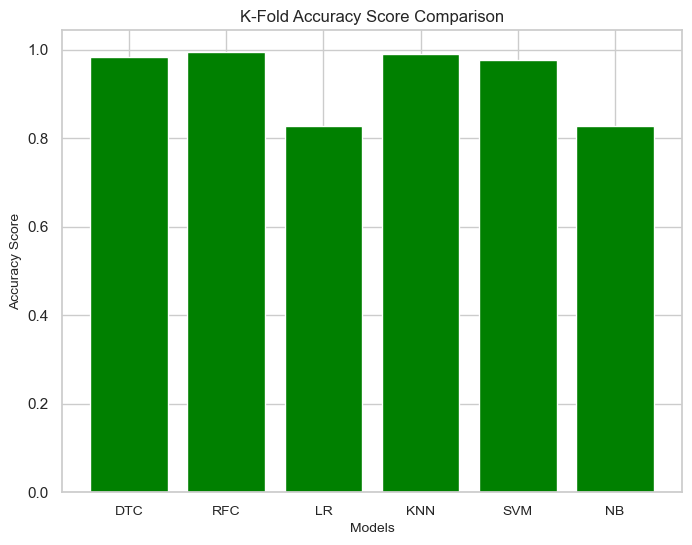

```python
kfold_labels = ['DTC', 'RFC', 'LR', 'KNN', 'SVM', 'NB']
kfold_results = [0.984018, 0.994667, 0.827035, 0.990684, 0.976035, 0.827053]

index = np.arange(len(kfold_labels))

plt.figure(figsize=(8,6)) # Size of the figure
sns.set(style="whitegrid") # Background grid


plt.bar(index, kfold_results, color='green')
plt.xlabel('Models', fontsize=10)
plt.ylabel('Accuracy Score', fontsize=10)
plt.xticks(index, kfold_labels, fontsize=10)
plt.title('K-Fold Accuracy Score Comparison')
plt.show()
```

We can see that the Random Forest Classifier (RFC) has the highest accuracy score.

# 6. Evaluating the Selected Models

# Random Forest Classifier

# Accuracy

```python
randomforest = RandomForestClassifier(random_state=0, max_depth=10, max_features=0.1, min_samples_leaf=3, min_samples_split=8, n_estimators=750) # gridsearch params
randomforest.fit(X_train, Y_train)

# Predictions on the testing set (X_test)
randomforest_predictions = randomforest.predict(X_test)

# Classification accuracy
randomforest_accuracy = accuracy_score(Y_test, randomforest_predictions)

print('Accuracy:', randomforest_accuracy)
```

```
Accuracy: 0.9787234042553191
```

From the accuracy, we can tell that the classifier has an excellent accuracy score of 0.9787 or 97.87%. This means that it makes mostly accurate predictions.

# Misclassification Rate

```python
# Misclassification Rate: How often is it wrong?
print('Misclassification Rate:', 1 - randomforest_accuracy)
```

```
Misclassification Rate: 0.021276595744680882
```

From the misclassification rate, we can tell that the classifier makes minimal errors.

# Comparing True and Predicted Values

```python
print('True:', Y_test.values[0:20])
print('Pred:', randomforest_predictions[0:20])
```

```
True: [1 1 0 0 1 1 1 1 1 0 1 1 1 1 1 1 0 1 1 0]
Pred: [1 1 0 0 1 1 1 1 1 0 1 0 1 1 1 1 0 0 1 0]
```

From these values, we can see that the classifier making excellent predictions.

# Confusion Matrix

```python
print(confusion_matrix(Y_test,randomforest_predictions))
```

```
[[93  1]
 [ 3 91]]
```

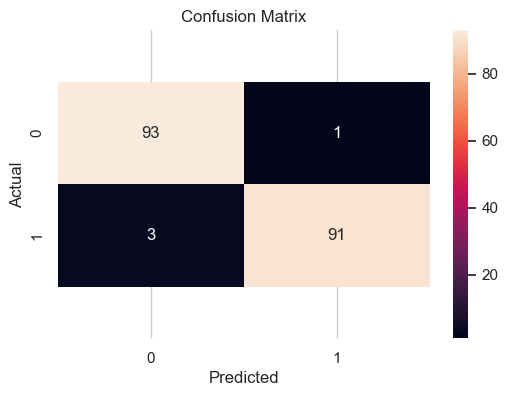

```python
# Confusion matrix for random forest predictions
randomforest_confusionmatrix = confusion_matrix(Y_test, randomforest_predictions)

# [row, column]
TP = randomforest_confusionmatrix[1, 1] # True Positive: Correctly predicted that patient has heart disease
TN = randomforest_confusionmatrix[0, 0] # True Negative: Correctly predicted that patient does not have heart disease
FP = randomforest_confusionmatrix[0, 1] # False Positive: Incorrectly Predicted that patient has heart disease
FN = randomforest_confusionmatrix[1, 0] # False Negative: Incorrectly predicted that patient does not have heart disease

# Visualize Confusion Matrix with Seaborn heatmap
plt.figure(figsize=(6,4)) # Size of the figure
cm = sns.heatmap(randomforest_confusionmatrix, annot=True)
plt.title('Confusion Matrix')
plt.xlabel('Predicted')
plt.ylabel('Actual')


# Fixing the sizing of the confusion matrix
bottom, top = cm.get_ylim()
cm.set_ylim(bottom + 0.5, top - 0.5)

plt.show()
```

Confusion Matrix Terminology

Basic Terms

True Positive (TP): Predicted yes, actual value is yes

True Negative (TN): Predicted no, actual value is no

False Positive (FP): Predicted yes, actual value is no (known as Type I error)

False Negative (FN): Predicted no, actual value is yes (known as Type II error)

Rates

True Positive Rate (Sensitivity): When the actual value is yes, how often does it predict yes?

False Positive Rate: When the actual value is no, how often does it predict yes?

True Negative Rate (Specificity): When the actual value is no, how often does it predict no?

Precision: When the classifier predicts yes, how often is it correct?

# True Positive Rate

```python
rf_tpr = TP/float(FN+TP)
print('True Positive Rate:', rf_tpr)
```

```
True Positive Rate: 0.9680851063829787
```

The classifier makes very accurate 'yes' predictions.

# False Positive Rate

```python
rf_fpr = FP/float(TN + FP)
print('False Positive Rate:', rf_fpr)
```

```
False Positive Rate: 0.010638297872340425
```

The classifier makes a very low amount of inaccurate 'yes' predictions

# True Negative Rate

```python
rf_tnr = TN/float(TN+FP)
print('True Negative Rate:', rf_tnr)
```

```
True Negative Rate: 0.9893617021276596
```

The classifier makes mostly accurate 'no' predictions.

# Precision

```python
print('Precision:', precision_score(Y_test, randomforest_predictions))
```

```
Precision: 0.9891304347826086
```

The classifier makes very precise 'yes' predictions.

# ROC Curve

Description of ROC Curve (Receiver Operating Characteristic Curve) An ROC Curve is a graph showing the performance of a classification model at all classification thresholds. It measures a model's ability to distinguish between classes, for example 0 and 1. In our case, it is the model's ability to distinguish whether a patient has a heart disease or not. The curve is plotted base on the True Positive Rate and False Positive Rate.

Description of AUC Score (Area Under the ROC Curve Score) AUC measures the entire two-dimensional area under the ROC Curve. It provides an aggregate measure of performance across all possible classification thresholds. A model that has an AUC Score of 0.0 makes every prediction incorrectly, whereas a model that has an AUC Score of 1.0 makes every prediction correctly.

```python
# Assigning rf_pred_proba as the predicted probabilities of class 1
rf_pred_proba = randomforest.predict_proba(X_test)[:,1]
```

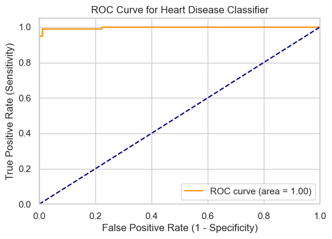

```python
fpr, tpr, thresholds = roc_curve(Y_test, rf_pred_proba)
# Pass the true values of the testing set, followed by the predicted probabilities for class 1

roc_auc = roc_auc_score(Y_test, rf_pred_proba)
# Assign roc_auc as the AUC Score which will be used as the value in the legend

# Plotting the ROC Curve
plt.figure(figsize=(6,4)) # Size of the figure
plt.plot(fpr, tpr, color='darkorange', label='ROC curve (area = %0.2f)' % roc_auc) # label to display the previously calculated AUC Score (roc_auc_score)
plt.plot([0, 1], [0, 1], color='navy', linestyle='--')
plt.xlim([0.0, 1.0])
plt.ylim([0.0, 1.05])
plt.rcParams['font.size'] = 12
plt.title('ROC Curve for Heart Disease Classifier')
plt.xlabel('False Positive Rate (1 - Specificity)')
plt.ylabel('True Positive Rate (Sensitivity)')
plt.legend(loc="lower right")
plt.grid(True) # To display the grid
plt.show()
```

Here, we can see that the AUC Score is very high. The model makes almost accurate predictions.

# Splitting the data

```python
X = df.drop(columns='target',axis=1)
Y = df['target']
```

```python
print(X)
print(Y)
```

```
      age  chest_pain  rest_blood_pressure  cholesterol  max_heart_rate  \
0      52           0                  125          212             168
1      53           0                  140          203             155
2      70           0                  145          174             125
3      61           0                  148          203             161
4      62           0                  138          294             106
...   ...         ...                  ...          ...             ...
1020   59           1                  140          221             164
1021   60           0                  125          258             141
1022   47           0                  110          275             118
1023   50           0                  110          254             159
1024   54           0                  120          188             113

      exercise_induced_angina  st_depression  st_slope  num_major_vessels  \
0                           0            1.0         2                  2
```

[output cut: 37 more lines]

# Training and Testing Data

```python
from sklearn.model_selection import train_test_split
X_train,X_test,Y_train,Y_test = train_test_split(X,Y,test_size=0.2,stratify=Y,random_state=2)
```

```python
print(X.shape, X_train.shape, X_test.shape)
```

```
(940, 10) (752, 10) (188, 10)
```

```python
import joblib

# Save the model to a file
model_filename = 'heart_model.pkl'
joblib.dump(model, model_filename)
```

```
['heart_model.pkl']
```

# Building The Predictive System

```python
print(df)
```

```
      age  chest_pain  rest_blood_pressure  cholesterol  max_heart_rate  \
0      52           0                  125          212             168
1      53           0                  140          203             155
2      70           0                  145          174             125
3      61           0                  148          203             161
4      62           0                  138          294             106
...   ...         ...                  ...          ...             ...
1020   59           1                  140          221             164
1021   60           0                  125          258             141
1022   47           0                  110          275             118
1023   50           0                  110          254             159
1024   54           0                  120          188             113

      exercise_induced_angina  st_depression  st_slope  num_major_vessels  \
0                           0            1.0         2                  2
```

[output cut: 25 more lines]

```python
# Create and train the RandomForestClassifier model
model = RandomForestClassifier()
model.fit(X_train, Y_train)


# Define the feature names
feature_names = ['age', 'chest_pain', 'rest_blood_pressure', 'cholesterol', 'max_heart_rate', 'exercise_induced_angina', 'st_depression', 'st_slope', 'num_major_vessels', 'thalassaemia']

# Now use the trained model to make predictions
input_data = np.array([[52, 0, 180, 212, 168, 0, 0.0, 2, 2, 3]])
prediction = model.predict(input_data)

if prediction[0] == 0:
    print("The Person does not have any Heart Disease")
else:
    print("The Person has Heart Disease")
```

```
The Person does not have any Heart Disease
```

# Model Interpretability

```python
!pip install lime
```

```python
X_test.iloc[8]
```

```
age                         57.0
chest_pain                   2.0
rest_blood_pressure        128.0
cholesterol                229.0
max_heart_rate             150.0
exercise_induced_angina      0.0
st_depression                0.4
st_slope                     1.0
num_major_vessels            1.0
thalassaemia                 3.0
Name: 39, dtype: float64
```

```python
from sklearn.ensemble import RandomForestClassifier

class ProbabilisticRandomForestWrapper:
    def __init__(self, model):
        self.model = model

    def predict_proba(self, X):
        predictions = self.model.predict(X)
        # Assuming binary classification, you can adjust this for multiclass
        proba = self.model.predict_proba(X)
        return proba

# Create a LIME explainer using the wrapper
wrapper_model = ProbabilisticRandomForestWrapper(model)
explainer = LimeTabularExplainer(X_train, mode="classification")

# Use an input data point from X_test
input_data = X_test.iloc[8]

explanation = explainer.explain_instance(input_data, wrapper_model.predict_proba)
explanation.show_in_notebook()
```

[output not shown]

```
X does not have valid feature names, but RandomForestClassifier was fitted with feature names
X does not have valid feature names, but RandomForestClassifier was fitted with feature names
```